# Entrega 3: Estimación en sistemas lineales con observaciones inciertas

Juan Rubio Cobeta

10 de diciembre de 2025

# 1 EJERCICIO 1

Consideremos el sistema dinámico lineal en tiempo discreto con observaciones inciertas definido por las siguientes ecuaciones en diferencias estocásticas:

$$\begin{aligned}
x(k+1) &= \Phi(k+1, k)x(k) + \Gamma(k+1, k)w(k), & k \ge 0,
\quad x(0)=x_0 \\
z(k) &= \gamma(k)H(k)x(k) + v(k), & k \ge 0
\end{aligned}$$

El sistema satisface las siguientes hipótesis estructurales y estocásticas:

1. **Condición Inicial:** El estado inicial $x_0$ es un vector aleatorio $n$-dimensional gaussiano centrado, caracterizado por:
   $$E[x_0] = 0, \quad E[x_0
   x_0^T] = P_0$$
2. **Ruido del Proceso:** La sucesión $\{w(k); k \ge 0\}$ es un proceso de ruido blanco gaussiano centrado con covarianza:
   $$E[w(k)w^T(j)] = Q(k)\delta_{kj}$$
   donde $\delta_{kj}$ es la delta de Kronecker.
3. **Incertidumbre en la Observación:** El proceso multiplicativo $\{\gamma(k); k \ge 0\}$ es una sucesión de variables aleatorias independientes de Bernoulli, que modela la presencia de la señal en la medida:
   $$P(\gamma(k)=1) = p(k), \quad P(\gamma(k)=0) =
   1-p(k)$$
4. **Ruido de Medida:** La sucesión $\{v(k); k \ge 0\}$ es un ruido blanco gaussiano centrado con covarianza definida positiva:
   $$E[v(k)v^T(j)] = R(k)\delta_{kj}, \quad R(k) >
   0$$
5. **Independencia Mutua:** El estado inicial $x_0$ y los procesos estocásticos $\{w(k)\}$, $\{v(k)\}$ y $\{\gamma(k)\}$ son mutuamente independientes para todo $k \ge 0$.

## 1.1 Apartado a):

El objetivo es demostrar que la matriz de covarianzas del proceso de innovación, definida como $\Pi(k) = E[\tilde{z}(k/k-1)\tilde{z}^T(k/k-1)]$, satisface la siguiente expresión:

$$\Pi(k) = p(k)(1-p(k))H(k)D(k)H^T(k) + p^2(k)H(k)P(k/k-1)H^T(k) + R(k)$$

### 1.1.1 Definición del proceso de innovación

La innovación se define como la diferencia entre la observación actual y su predicción óptima basada en la información previa:

$$\tilde{z}(k/k-1) = z(k) - \hat{z}(k/k-1)$$

Calculamos el predictor de la observación $\hat{z}(k/k-1)$. Dado que $v(k)$ y $\gamma(k)$ son independientes de las observaciones pasadas, y $E[v(k)]=0$, tenemos:

$$\begin{aligned}
\hat{z}(k/k-1) &= E[z(k) | Z_{k-1}] \\
&= E[\gamma(k)H(k)x(k) + v(k) | Z_{k-1}] \\
&= E[\gamma(k)]H(k)E[x(k) | Z_{k-1}] + 0 \\
&= p(k)H(k)\hat{x}(k/k-1)
\end{aligned}$$

Sustituimos $z(k)$ y $\hat{z}(k/k-1)$ en la expresión de la innovación:

$$\tilde{z}(k/k-1) = [\gamma(k)H(k)x(k) + v(k)] - p(k)H(k)\hat{x}(k/k-1)$$

### 1.1.2 Descomposición de la innovación

Para calcular la varianza, es útil expresar la innovación en términos del error de estimación del estado, $\tilde{x}(k/k-1) = x(k) - \hat{x}(k/k-1)$. Despejando $\hat{x}(k/k-1) = x(k) - \tilde{x}(k/k-1)$ y sustituyendo arriba:

$$\begin{aligned}
\tilde{z}(k/k-1) &= \gamma(k)H(k)x(k) + v(k) - p(k)H(k)[x(k) -
\tilde{x}(k/k-1)] \\
&= \gamma(k)H(k)x(k) - p(k)H(k)x(k) + p(k)H(k)\tilde{x}(k/k-1) +
v(k)
\end{aligned}$$

Agrupamos los términos para identificar las fuentes de aleatoriedad independientes:

$$\tilde{z}(k/k-1) = \underbrace{[\gamma(k) -
p(k)]H(k)x(k)}_{\text{Término A}} +
\underbrace{p(k)H(k)\tilde{x}(k/k-1)}_{\text{Término B}} +
\underbrace{v(k)}_{\text{Término C}}$$

### 1.1.3 Cálculo de la matriz de covarianzas

Calculamos $\Pi(k) = E[\tilde{z}(k/k-1)\tilde{z}^T(k/k-1)]$. Debido a las hipótesis de independencia del sistema (el ruido blanco $v(k)$ y la variable Bernoulli $\gamma(k)$ son independientes entre sí y respecto al estado $x(k)$ y al error pasado), los términos cruzados (covarianzas cruzadas) se anulan:

- $E[AB^T] = 0$: Porque $\gamma(k)$ es independiente del error de estimación.
- $E[AC^T] = 0$: Porque $\gamma(k)$ y $x(k)$ son independientes de $v(k)$.
- $E[BC^T] = 0$: Porque el error pasado es independiente del ruido presente.

Por tanto, la covarianza es la suma de las covarianzas de los tres términos individuales:

$$\Pi(k) = E[AA^T] + E[BB^T] + E[CC^T]$$

Analizamos cada término:

**Término 1 ($AA^T$): Incertidumbre de observación**
$$\begin{aligned}
E[AA^T] &= E\left[ (\gamma(k)-p(k))^2 H(k)x(k)x^T(k)H^T(k) \right]
\\
&= E\left[ (\gamma(k)-p(k))^2 \right] H(k) E\left[ x(k)x^T(k)
\right] H^T(k)
\end{aligned}$$
Sabemos que la varianza de una variable Bernoulli es $\text{Var}(\gamma(k)) = p(k)(1-p(k))$ y definimos la matriz de segundos momentos del estado como $D(k) = E[x(k)x^T(k)]$.
$$E[AA^T] = p(k)(1-p(k))H(k)D(k)H^T(k)$$

**Término 2 ($BB^T$): Error de estimación**
$$\begin{aligned}
E[BB^T] &= p^2(k) H(k) E\left[ \tilde{x}(k/k-1)\tilde{x}^T(k/k-1)
\right] H^T(k) \\
&= p^2(k) H(k) P(k/k-1) H^T(k)
\end{aligned}$$

**Término 3 ($CC^T$): Ruido de medida**
$$E[CC^T] = E[v(k)v^T(k)] = R(k)$$

### 1.1.4 Resultado Final

Sumando los tres componentes, obtenemos la expresión deseada:

$$\Pi(k) = p(k)(1-p(k))H(k)D(k)H^T(k) + p^2(k)H(k)P(k/k-1)H^T(k) + R(k)$$

**Verificación para $k=0$:**

En el instante inicial, el predictor es $\hat{x}(0/-1) = E[x_0] = 0$, por lo que el error es $\tilde{x}(0/-1) = x_0$. Esto implica que $P(0/-1) = E[x_0 x_0^T] = P_0$. Asimismo, $D(0) = E[x_0 x_0^T] = P_0$.

Sustituyendo en la fórmula general:
$$\begin{aligned}
\Pi(0) &= [p(0)(1-p(0))]H(0)P_0H^T(0) + p^2(0)H(0)P_0H^T(0) + R(0)
\\
&= [p(0) - p^2(0) + p^2(0)] H(0)P_0H^T(0) + R(0) \\
&= p(0)H(0)P_0H^T(0) + R(0)
\end{aligned}$$

Lo cual coincide con la expresión dada en el enunciado. **Q.E.D.**

## 1.2 Apartado b)

El objetivo es obtener el estimador de suavizamiento de punto fijo $\hat{x}(L/k)$ para un instante fijo $L$ utilizando las observaciones hasta el instante $k$ ($k > L$).

Utilizando el **Lema de Proyecciones Ortogonales**, podemos expresar el estimador en el instante $k$ como una actualización del estimador en $k-1$ más un término de corrección basado en la nueva información (la innovación $\tilde{z}(k/k-1)$):

$$\hat{x}(L/k) = \hat{x}(L/k-1) + K_s(k)\tilde{z}(k/k-1)$$

Donde $K_s(k)$ es la matriz de ganancia del suavizador.

### 1.2.1 Cálculo de la Ganancia del Suavizador $K_s(k)$

Por el Lema de Proyecciones, la ganancia óptima que minimiza el error cuadrático medio está dada por:

$$K_s(k) = E[x(L)\tilde{z}^T(k/k-1)] \Pi^{-1}(k)$$

Desarrollamos el término de esperanza cruzada $E[x(L)\tilde{z}^T(k/k-1)]$. Recordamos la descomposición de la innovación $\tilde{z}(k/k-1)$ deducida en el apartado anterior:

$$\tilde{z}(k/k-1) = [\gamma(k)-p(k)]H(k)x(k) + p(k)H(k)\tilde{x}(k/k-1) +
v(k)$$

Multiplicamos por $x(L)$ y tomamos la esperanza. Debido a la independencia de $\gamma(k)$ y $v(k)$ respecto al estado $x(L)$ y al pasado, los primeros y últimos términos se anulan:

1. $E[x(L)(\gamma(k)-p(k)) \dots] = 0$
2. $E[x(L)v^T(k)] = 0$

Nos queda el término central:
$$\begin{aligned}
E[x(L)\tilde{z}^T(k/k-1)] &= E[x(L) \tilde{x}^T(k/k-1) H^T(k) p(k)]
\\
&= E[x(L) \tilde{x}^T(k/k-1)] H^T(k) p(k)
\end{aligned}$$

Introducimos el error de suavizamiento $\tilde{x}(L/k-1) = x(L) - \hat{x}(L/k-1)$. Dado que $\hat{x}(L/k-1)$ es una proyección sobre el espacio de observaciones $Z_{k-1}$ y $\tilde{x}(k/k-1)$ es ortogonal a dicho espacio (por propiedad del filtro), podemos sustituir $x(L)$ por $\tilde{x}(L/k-1)$ en la esperanza:

$$E[x(L)\tilde{x}^T(k/k-1)] = E[\tilde{x}(L/k-1)\tilde{x}^T(k/k-1)]$$

Definimos la matriz auxiliar de covarianza cruzada como $\Sigma(k) \triangleq E[\tilde{x}(L/k-1)\tilde{x}^T(k/k-1)]$. Por tanto, la ganancia del suavizador es:

$$K_s(k) = \Sigma(k)H^T(k)p(k)\Pi^{-1}(k)$$

### 1.2.2 Ecuación Recursiva para $\Sigma(k)$

Necesitamos una recursión para calcular $\Sigma(k)$. Partimos de la ecuación de evolución del error de predicción del filtro:

$$\tilde{x}(k/k-1) = \Phi(k,k-1)\tilde{x}(k-1/k-1) + \Gamma(k,k-1)w(k-1)$$

Sustituimos esto en la definición de $\Sigma(k)$:

$$\begin{aligned}
\Sigma(k) &= E[\tilde{x}(L/k-1) \{ \Phi(k,k-1)\tilde{x}(k-1/k-1) +
\Gamma(k,k-1)w(k-1) \}^T ] \\
&= E[\tilde{x}(L/k-1)\tilde{x}^T(k-1/k-1)]\Phi^T(k,k-1)
\end{aligned}$$
(El término con $w(k-1)$ se anula por independencia).

Ahora, recordamos que el estimador suavizado en la etapa anterior es $\hat{x}(L/k-1) = \hat{x}(L/k-2) + K_s(k-1)\tilde{z}(k-1/k-2)$. Restando esto de $x(L)$, obtenemos la recursión del error:

$$\tilde{x}(L/k-1) = \tilde{x}(L/k-2) - K_s(k-1)\tilde{z}(k-1/k-2)$$

Sustituimos esto en la esperanza anterior:

$$E [ \{ \tilde{x}(L/k-2) - K_s(k-1)\tilde{z}(k-1/k-2) \}
\tilde{x}^T(k-1/k-1) ] \Phi^T(k,k-1)$$

Sabemos que el error de filtrado $\tilde{x}(k-1/k-1)$ es ortogonal a la innovación $\tilde{z}(k-1/k-2)$ (propiedad fundamental del filtro óptimo). Por tanto, el segundo término dentro del corchete es cero. Nos queda:

$$E[\tilde{x}(L/k-2)\tilde{x}^T(k-1/k-1)]\Phi^T(k,k-1)$$

Finalmente, expresamos el error de filtrado en función del error de predicción usando la ganancia del filtro $K_f$:
$$\tilde{x}(k-1/k-1) = [I - K_f(k-1)p(k-1)H(k-1)]\tilde{x}(k-1/k-2) +
\dots$$
Sustituyendo y tomando esperanzas, llegamos a la recursión final para $\Sigma(k)$:

$$\Sigma(k) = \Sigma(k-1) [I - K_f(k-1)p(k-1)H(k-1)]^T \Phi^T(k,k-1)$$

### 1.2.3 Resumen del Algoritmo

El algoritmo de suavizamiento punto fijo para sistemas con observaciones inciertas se inicializa en $k=L$ con los valores del filtro $\hat{x}(L/L)$ y $P(L/L)$. Para $k = L+1, L+2, \dots$:

1. **Matrices del Filtro (Nahi):** Se asume conocido el cálculo de $\Pi(k)$, $\tilde{z}(k/k-1)$, $K_f(k)$ y $P(k/k)$.
2. **Actualización de Matriz Auxiliar:**
   $$\Sigma(k) = \Sigma(k-1) [I - K_f(k-1)p(k-1)H(k-1)]^T \Phi^T(k,k-1)$$
   *Inicialización:* $\Sigma(L+1) = P(L/L)\Phi^T(L+1, L)$.
3. **Ganancia de Suavizamiento:**
   $$K_s(k) = \Sigma(k)H^T(k)p(k)\Pi^{-1}(k)$$
4. **Estimación Suavizada:**
   $$\hat{x}(L/k) = \hat{x}(L/k-1) + K_s(k)\tilde{z}(k/k-1)$$

## 1.3 Apartado c)

Consideramos el sistema escalar específico dado por:
$$\begin{aligned}
x(k+1) &= 0.95x(k) + w(k) \\
z(k) &= \gamma(k)x(k) + v(k)
\end{aligned}$$
Con parámetros: $\Phi=0.95$, $\Gamma=1$, $H=1$, $Q=0.1$, $R=0.5$, $p=0.5$.

El **ciclo computacional** para la implementación conjunta del filtro y el suavizador de punto fijo en un instante $L$ fijo es el siguiente:

### 1.3.1 Inicialización ($k=0$)

Se inicializan las variables del filtro con la media y covarianza a priori:
$$\begin{aligned}
\hat{x}(0/-1) &= 0 \\
P(0/-1) &= P_0 = 1 \\
D(0) &= P_0 = 1
\end{aligned}$$

### 1.3.2 Bucle de Filtrado (Para $k = 0, 1, \dots, N$)

En cada instante $k$, se ejecutan los siguientes pasos secuenciales:

1. **Cálculo de la covarianza de la innovación ($\Pi(k)$):**
   $$\Pi(k) = p(1-p)D(k) + p^2 P(k/k-1) + R$$
   *(Nota: Se ha usado $H=1$)*.
2. **Cálculo de la ganancia del filtro ($K(k)$):**
   $$K(k) = p P(k/k-1) \Pi^{-1}(k)$$
3. **Cálculo de la innovación ($\tilde{z}(k)$):**
   $$\tilde{z}(k/k-1) = z(k) -
   p\hat{x}(k/k-1)$$
4. **Actualización de la estimación (Filtrado):**
   $$\hat{x}(k/k) = \hat{x}(k/k-1) +
   K(k)\tilde{z}(k/k-1)$$
5. **Actualización de la covarianza del error ($P(k/k)$):**
   $$P(k/k) = P(k/k-1) - p K(k)
   P(k/k-1)$$
6. **Predicción para el siguiente instante ($k+1$):**
   $$\begin{aligned}
   \hat{x}(k+1/k) &= \Phi \hat{x}(k/k) \\
   P(k+1/k) &= \Phi^2 P(k/k) + Q \\
   D(k+1) &= \Phi^2 D(k) + Q
   \end{aligned}$$

### 1.3.3 Bucle del Suavizador de Punto Fijo (Para un $L$ fijo)

Queremos mejorar la estimación de $x(L)$ usando datos futuros $z(k)$ con $k > L$. **Inicialización ($k=L$):**
$$\hat{x}(L/L) \quad \text{(Obtenido del filtro)}$$
$$\Sigma(L+1) = P(L/L)\Phi \quad \text{(Matriz auxiliar inicial)}$$

**Iteración (Para $k = L+1, \dots, N$):**

1. **Ganancia del Suavizador:**
   $$K_s(k) = \Sigma(k) p \Pi^{-1}(k)$$
   *(Usa $\Pi(k)$ calculado en el filtro)*.
2. **Actualización de la Estimación Suavizada:**
   $$\hat{x}(L/k) = \hat{x}(L/k-1) +
   K_s(k)\tilde{z}(k/k-1)$$
   *(Usa $\tilde{z}$ del filtro)*.
3. **Actualización de la Matriz Auxiliar:**
   $$\Sigma(k+1) = \Sigma(k) [1 - K(k)p] \Phi$$
   *(Usa $K(k)$ del filtro)*.

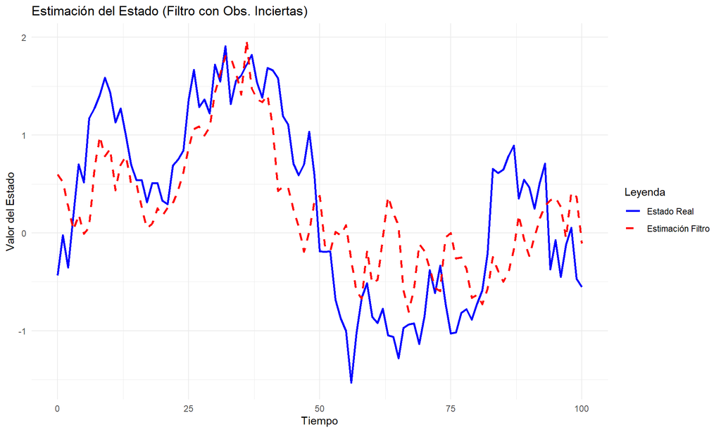

```r
library(tidyverse)
# --- Parámetros del Sistema ---
set.seed(123) # Para reproducibilidad
N_iter <- 100 # Número de iteraciones
Phi <- 0.95
Gamma <- 1
H <- 1
Q <- 0.1
R <- 0.5
P0 <- 1
p_prob <- 0.5 # Probabilidad de señal presente p(k)

# --- 1. Simulación del Sistema Real ---
# Reservamos memoria
x <- numeric(N_iter + 1)
z <- numeric(N_iter + 1)
gamma <- rbinom(N_iter + 1, 1, p_prob) # Variable Bernoulli

# Condiciones iniciales
x[1] <- rnorm(1, 0, sqrt(P0)) # x(0)

# Bucle de simulación
for (k in 1:N_iter) {
  # Ruido de medida
  v <- rnorm(1, 0, sqrt(R))
  # Observación z(k) = gamma(k)H x(k) + v(k)
  # Nota: k en código corresponde al tiempo k-1 real en el bucle,
  # pero aquí indexamos x[k] como el estado actual.
  z[k] <- gamma[k] * H * x[k] + v

  # Evolución del estado x(k+1)
  w <- rnorm(1, 0, sqrt(Q))
  x[k+1] <- Phi * x[k] + w
}
# La última observación para x[N_iter+1]
z[N_iter+1] <- gamma[N_iter+1] * H * x[N_iter+1] + rnorm(1, 0, sqrt(R))


# --- 2. Implementación del Filtro (Nahi) ---
# Almacenamiento
x_hat_pred <- numeric(N_iter + 1) # x(k/k-1)
x_hat_filt <- numeric(N_iter + 1) # x(k/k)
P_pred <- numeric(N_iter + 1)     # P(k/k-1)
P_filt <- numeric(N_iter + 1)     # P(k/k)
D <- numeric(N_iter + 1)          # D(k)
Pi_innov <- numeric(N_iter + 1)   # Covarianza innovación
z_tilde <- numeric(N_iter + 1)    # Innovación
K_gain <- numeric(N_iter + 1)     # Ganancia

# Inicialización k=0 (índice 1 en R)
x_hat_pred[1] <- 0
P_pred[1] <- P0
D[1] <- P0

for (k in 1:(N_iter + 1)) {
  # 1. Covarianza Innovación Pi(k)
  # Termino 1: p(1-p)HDH'
  term1 <- p_prob * (1 - p_prob) * H * D[k] * H
  # Termino 2: p^2 H P H'
  term2 <- p_prob^2 * H * P_pred[k] * H
  Pi_innov[k] <- term1 + term2 + R

  # 2. Ganancia K(k)
  K_gain[k] <- p_prob * P_pred[k] * H * (1/Pi_innov[k])

  # 3. Innovación z_tilde(k)
  z_tilde[k] <- z[k] - p_prob * H * x_hat_pred[k]

  # 4. Actualización Estado (Filtrado) x(k/k)
  x_hat_filt[k] <- x_hat_pred[k] + K_gain[k] * z_tilde[k]

  # 5. Actualización Covarianza P(k/k)
  # Forma estabilizada: (I - KpH)P
  P_filt[k] <- (1 - K_gain[k] * p_prob * H) * P_pred[k]

  # 6. Predicción (k+1) - Solo si no es el último paso
  if (k <= N_iter) {
    x_hat_pred[k+1] <- Phi * x_hat_filt[k]
    P_pred[k+1] <- Phi * P_filt[k] * Phi + Q # Gamma=1
    D[k+1] <- Phi * D[k] * Phi + Q
  }
}

# --- 3. Implementación del Suavizador Punto Fijo ---
# Objetivo: Estimar x(L) dado datos hasta k.
# Elegimos un instante fijo L a mitad de la simulación
L_idx <- 20 # Corresponde a k=19 (tiempo real)
L_real <- L_idx - 1

# El suavizador empieza a funcionar cuando k > L
# Almacenamos la estimación de x(L) a medida que k avanza
x_smooth_L <- numeric(N_iter + 1)
x_smooth_L[1:L_idx] <- NA # No existe suavizado antes de L

# Inicialización en k=L (índice L_idx)
# El estimador suavizado inicial es igual al filtrado en ese instante
x_smooth_L[L_idx] <- x_hat_filt[L_idx]
# Matriz auxiliar Sigma inicial: Sigma(L+1) = P(L/L) * Phi'
Sigma <- P_filt[L_idx] * Phi

# Bucle desde L+1 hasta el final
for (k in (L_idx + 1):(N_iter + 1)) {
  # Ganancia del Suavizador Ks(k)
  # Usa Pi(k) del filtro almacenado
  Ks <- Sigma * H * p_prob * (1/Pi_innov[k])

  # Actualización del estimador suavizado x(L/k)
  # Usa la innovación z_tilde(k) del filtro
  x_smooth_L[k] <- x_smooth_L[k-1] + Ks * z_tilde[k]

  # Actualización de Sigma para el siguiente paso
  # Usa la ganancia del filtro K(k) almacenada
  Sigma <- Sigma * (1 - K_gain[k] * p_prob * H) * Phi
}

# --- 4. Visualización de Resultados ---
df_filter <- data.frame(
  Tiempo = 0:N_iter,
  Real = x,
  Estimado = x_hat_filt,
  Tipo = "Filtro (Nahi)"
)

# Gráfico del Filtro
p1 <- ggplot(df_filter, aes(x=Tiempo)) +
  geom_line(aes(y=Real, color="Estado Real"), linewidth=1) +
  geom_line(aes(y=Estimado, color="Estimación Filtro"), linetype="dashed", linewidth=1) +
  labs(title = "Estimación del Estado (Filtro con Obs. Inciertas)",
       y = "Valor del Estado", color = "Leyenda") +
  theme_minimal() +
  scale_color_manual(values=c("blue", "red"))

# Gráfico del Suavizador para el instante L
# Comparamos el valor VERDADERO en L fijo vs la evolución de la estimación
df_smooth <- data.frame(
  Tiempo = L_real:N_iter,
  Estimacion_L = x_smooth_L[L_idx:(N_iter+1)],
  Valor_Real_L = x[L_idx] # Valor constante
)

p2 <- ggplot(df_smooth, aes(x=Tiempo)) +
  geom_hline(aes(yintercept=Valor_Real_L, color="Valor Real x(L)"), linewidth=1) +
  geom_line(aes(y=Estimacion_L, color="Est. Suavizada x(L/k)"), linewidth=1) +
  labs(title = paste("Evolución de la Estimación Suavizada para L =", L_real),
       subtitle = "Cómo mejora la estimación de x(L) al recibir más datos futuros",
       y = "Valor Estimado de x(L)", x = "Tiempo actual de observación (k)",
       color = "Leyenda") +
  theme_minimal() +
  scale_color_manual(values=c("darkgreen", "black"))

# Mostrar gráficos
print(p1)
```

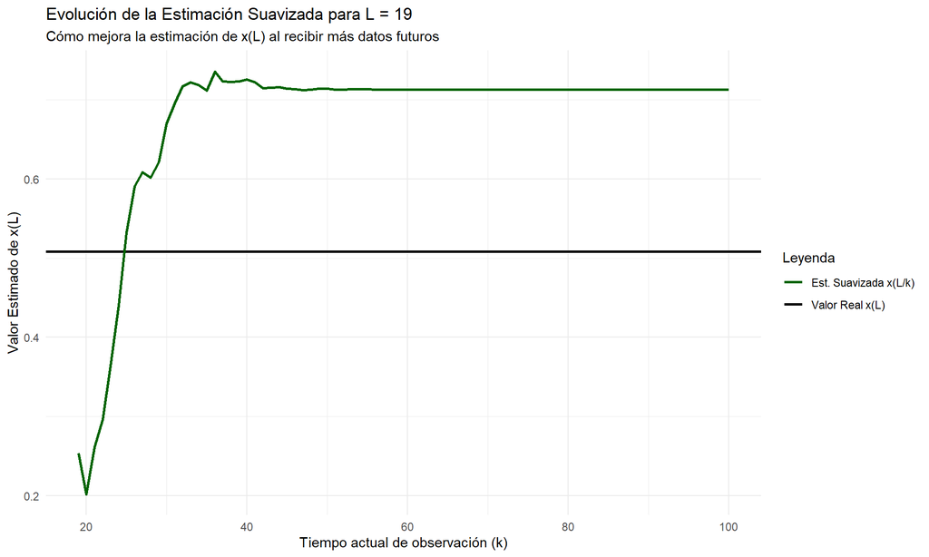

```r
print(p2)
```